# Peer-graded Assignment: Course Project 1

## Loading and preprocessing the data

Unzip file and load data, change “character”" to “Date”.

```r
setwd("D:/R Coursera/Reproducible Research/Activity Monitoring Data")
unzip("repdata%2Fdata%2Factivity.zip", exdir = "Activity Monitoring Data")
AMD <- read.csv("activity.csv", colClasses = c("date" = "Date" ))
```

Calculate the mean and median value for steps taken each day.

```r
stepsDay     <- tapply(AMD$steps, format(AMD$date, '%m-%d'), sum)
stepsMean    <- mean(stepsDay, na.rm = TRUE)
stepsMedian  <- median(stepsDay, na.rm = TRUE)
```

Here they are:

```r
stepsMean
```

```
## [1] 10766.19
```

```r
stepsMedian
```

```
## [1] 10765
```

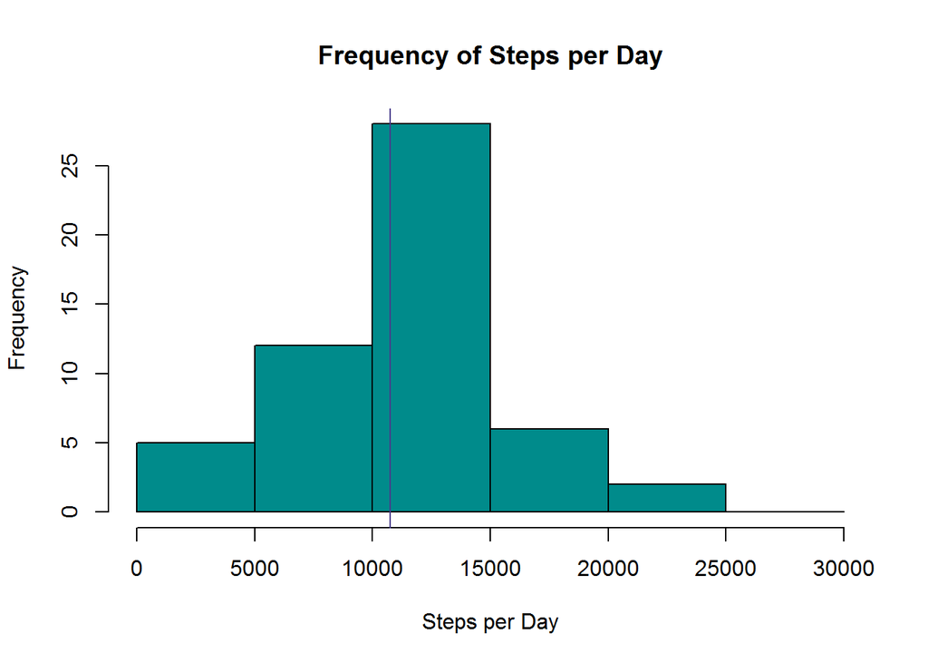

## What is the average daily activity pattern?

Load dplyr package, create a variable that counts steps for each interval.

```r
IntervalSteps     <- group_by(AMD, AMD$interval)
SumStepsInterval  <- summarise(IntervalSteps, count = n(),
                          steps  = mean(steps, na.rm = T))
```

Plot the time series with mean steps per interval

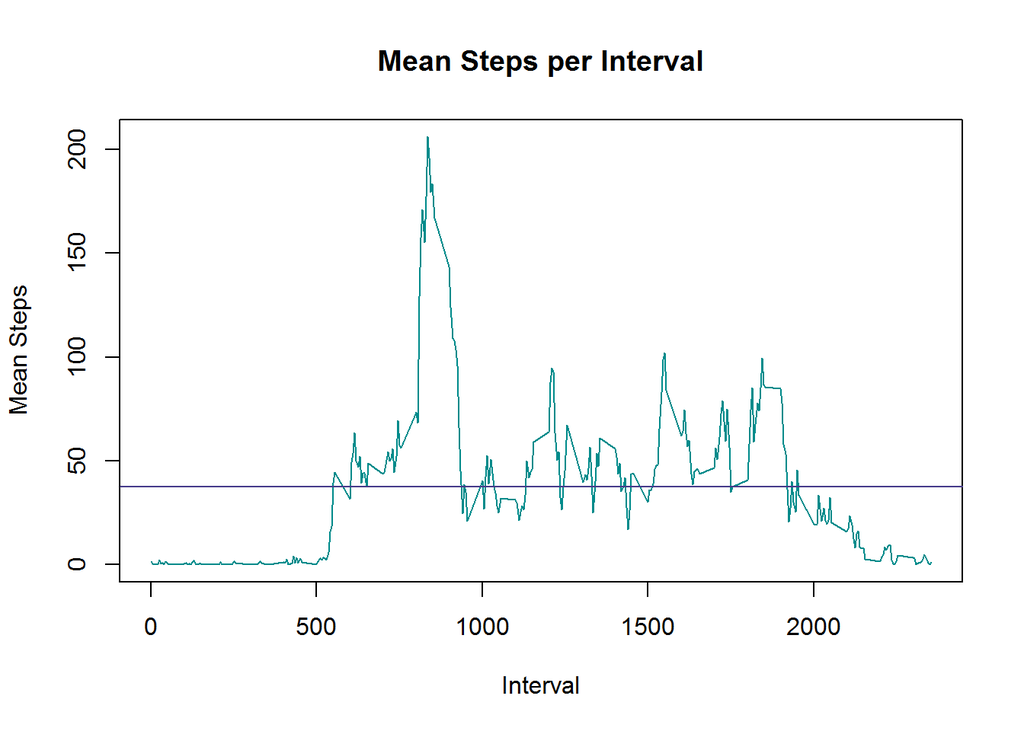

```r
plot(SumStepsInterval$`AMD$interval`, SumStepsInterval$steps, type = 'l',
       col =   "darkcyan", main = "Mean Steps per Interval", xlab = "Interval",
      ylab = "Mean Steps")

abline(h = mean(SumStepsInterval$steps), col = "slateblue4")
```

Which 5-minute interval, on average across all the days in the dataset, contains the maximum number of steps?

```r
StepsMax <- SumStepsInterval[which.max(SumStepsInterval$steps), ]$`AMD$interval`
StepsMax
```

```
## [1] 835
```

## Imputing missing values

Calculate and report the total number of missing values in the dataset (i.e. the total number of rows with NAs)

```r
na_count <- sum(is.na(AMD))
na_count
```

```
## [1] 2304
```

Devise a strategy for filling in all of the missing values in the dataset. The strategy does not need to be sophisticated. For example, you could use the mean/median for that day, or the mean for that 5-minute interval, etc.

Create a new dataset that is equal to the original dataset but with the missing data filled in.

```r
AMD2          <- AMD
allNA         <- is.na(AMD2$steps)
stepsmean     <- tapply(AMD2$steps, AMD2$interval, mean, na.rm=TRUE, simplify = TRUE)
AMD2$steps[allNA]   <- stepsmean
sum(is.na(AMD2))
```

```
## [1] 0
```

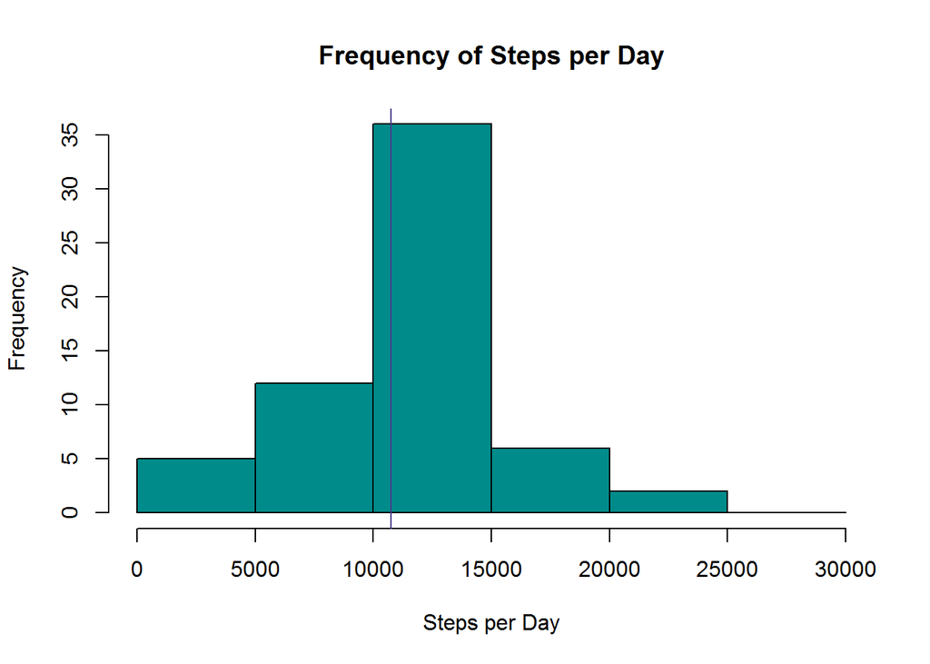

## Are there differences in activity patterns between weekdays and weekends?

```r
AMD3 <- AMD2%>%
    mutate(typeofday = ifelse(weekdays(AMD2$date) == "Sonntag" | weekdays(AMD2$date)     == "Samstag", "Weekend", "Weekday"))

summary(AMD3)
```

```
##      steps             date               interval       typeofday
##  Min.   :  0.00   Min.   :2012-10-01   Min.   :   0.0   Length:17568
##  1st Qu.:  0.00   1st Qu.:2012-10-16   1st Qu.: 588.8   Class :character
##  Median :  0.00   Median :2012-10-31   Median :1177.5   Mode  :character
##  Mean   : 37.38   Mean   :2012-10-31   Mean   :1177.5
##  3rd Qu.: 27.00   3rd Qu.:2012-11-15   3rd Qu.:1766.2
##  Max.   :806.00   Max.   :2012-11-30   Max.   :2355.0
```

[figure not shown]

```r
IntervalStepsMean <- aggregate(steps ~ interval, data = AMD3, FUN = mean, na.rm = TRUE)
g <- ggplot(AMD3, aes(x = interval , y = steps, color = typeofday))
g <- g +  geom_line() +
     labs(title = "Average steps by type of day",
           x = "Interval",
           y = "Mean number of Steps")
g <- g +   facet_wrap( ~ typeofday, ncol = 1, nrow = 2)
  plot(g)
```